# Project: Investigate a Soccer Database

- Introduction
- Data Wrangling
- Exploratory Data Analysis
- Conclusions

## Introduction

> **What is Soccer Database?**  
> The ultimate Soccer Database is a collection of tables that contain information regarding players, teams, matches, and more.  
> I shall first introduce you to the structure of the Tables :

`Country`

| Attribute | Type | Describtion |
| --- | --- | --- |
| id | integer | table identifier |
| name | text | country name |

`League`

| Attribute | Type | Describtion |
| --- | --- | --- |
| id | integer | table identifier |
| country_id | integer | foreign key for country table |
| name | text | name of league |

`Match`

| Attribute | Type | Describtion |
| --- | --- | --- |
| id | integer | table identifier |
| country_id | integer | foreign key for country table |
| league_id | integer | foreign key for the league |
| season | text | season eg.2018/2019 |
| stage | integer | stage number |
| date | text | the date of the match |
| home_team_api_id | integer | the foreign key for the team represents the team who plays in his stadium |
| away_team_api_id | integer | the foreign key for the team represents the team who doesn't play in his stadium |
| home_team_goal | integer | number of goals home team has scored in the match |
| away_team_goal | integer | number of goals away team has scored in the match |
| home_player_x1 | integer | position of the home player x axis |
| ................ ................ | ....... ....... | ..................................................... ..................................................... |
| away_player_x1 | integer | position of the away player x axis |
| ................ ................ | ....... ....... | ...................................................... ...................................................... |
| home_player_y1 | integer | position of the home player y axis |
| ................ ................ | ....... ....... | ...................................................... ...................................................... |
| away_player_y1 | integer | position of the away player y axis |
| ................ ................ | ....... ....... | ...................................................... ...................................................... |
| home_player_1 | integer | the foreign key for the player table represents the first player of the home team |
| ................ ................ | ....... ....... | ...................................................... ...................................................... |
| away_player_1 | integer | the foreign key for the player table represents the first player of the away team |
| ................ ................ | ....... ....... | ...................................................... ...................................................... |
| shoton | text | XML text to represent the id of each player who made a shot on the target |
| shotoff | text | XML text to represent the id of each player who made a shot off the target |
| goal | text | XML text to represent the ids of the players who scored goals and how many |
| foulcommit | text | XML text to represent the ids of the players who commit fouls |
| card | text | XML text to represent the ids of the players who took a [yellow-red] card |
| corner | text | XML text to represent the ids of the players who played corners |
| possession | text | XML text to represent home and away possession |
| B365H | numeric | Bookmaker or betting site odds in decimal format |
| B365D | numeric | Bookmaker or betting site odds in decimal format |
| ................ ................ | ....... ....... | ...................................................... ...................................................... |

`Player`

| Attribute | Type | Describtion |
| --- | --- | --- |
| id | integer | table identifier |
| player_api_id | integer | unique id |
| palyer_fifa_api_id | integer | unique id |
| palyer_name | text | name of the player |
| birthday | text | palyer birthday |
| weight | integer | weight of the player |
| height | integer | height of the player |

`Player_Attributes`

| Attribute | Type | Describtion |
| --- | --- | --- |
| id | integer | table identifier |
| player_api_id | integer | foreign key for player table |
| palyer_fifa_api_id | integer | foreign key for player table |
| date | text | date of the update |
| overall_rating | integer | fifa rating |
| potential | integer | fifa rating |
| preferred_foot | text | fifa rating |
| .................. .................. | ....... ....... | .................. .................. |

`Team`

| Attribute | Type | Describtion |
| --- | --- | --- |
| id | integer | table identifier |
| team_api_id | integer | unique id |
| team_fifa_api_id | integer | unique id |
| team_long_name | text | team long name |
| team_short_name | text | team short name |

`Team_Attributes`

| Attribute | Type | Describtion |
| --- | --- | --- |
| id | integer | table identifier |
| team_api_id | integer | foreign key for player table |
| team_fifa_api_id | integer | foreign key for player table |
| date | text | date of season |
| buildupplayspeed | integer | rank from 1 to 100 |
| buildupplayspeedclass | text | classification for build up speed |
| buildupplaydribbiling | integer | rank from 1 to 100 |
| buildupplaydribbilingclass | text | classification for build up dribbiling |
| .......................... .......................... | ....... ....... | ....................................... ....................................... |

> **Notes**

$\bullet$ the dots ....... in the tables above mean that the next attributes will have the same sequence and i did't mention them to save time  
$\bullet$ there isn't a key between team table and player table  
$\bullet$ I have used [tablesgenerator web](https://www.tablesgenerator.com/markdown_tables#) site to write these tables in the markdown cell  
$\bullet$ I have found a lot of information about betting websites [her](http://www.football-data.co.uk/notes.txt)

> **Questions**  
> 1) which team has improved through all seasons in Spain LIGA BBVA?  
> 2) How is the player's physical power related to weight and height?  
> 3) How did the number of red cards change from 2008 to 2016?

```python
import pandas as pd
import numpy as np
import matplotlib.pyplot as plt
import seaborn as sns
import os
from sqlalchemy import create_engine
from sqlalchemy.types import Integer
from bs4 import BeautifulSoup
%matplotlib inline
```

## Data Wrangling

> **Sections**:  
> $\triangleright$ Lodaing the data  
> $\triangleright$ General Properties  
> $\circ$ Teams Dataset  
> $\circ$ Players Dataset  
> $\circ$ Matches Dataset  
> $\triangleright$ Cleaning the data  
> $\circ$ Teams_Dataset  
> $\circ$ players_Dataset  
> $\circ$ Matches_Dataset

### Loading Data

**Loading Data** is one of the most easiest thing with **sql** ,but reading multiple tables each time we want to answer a question lead to code redundency so in the next cell i will make a two functions to do the following:

- Build a connection to our database
- Load the data into a dataframe
- Convert all the columns names to lowercase and replace spaces with "_"
- the second function will load a dataframe into our database

```python
def make_Query(query):
    """This function to make query from database.db
    inputs :
    query ----------> string --------> the query to be done
    outputs:
    df    ----------> dataframe-------> dataframe contains the query result
    """
    # the path of my database
    path = r"C:\Users\Eslam\Desktop\Eslam\Summer\Data analysis Udacity\Professional\Introduction to data analysis\Project 2\database.sqlite"
    #bulding a connection with create_engine object
    engine = create_engine('sqlite:///'+path)
    df = pd.read_sql(query, engine)
    df.rename(columns = lambda name:name.lower().replace(' ','_'),inplace = True)
    #   types and look for instances of missing or possibly errant data.
    return df
```

```python
def load_table( df, name, index = False, datatypes=None):
    """
    this function ask the user for dataframe to load it to our database
    inputs :
    df--------> DataFrame --------> dataframe to be converted into a table in database
    name------> string -----------> name of the table
    index-----> Boolean ----------> specify if the table will come with index or not
    datatypes-----> dictionary -----> specify datatype for each column such that column name is the key
    outputs :
    None
    """
    # the path of my database
    path = r"C:\Users\Eslam\Desktop\Eslam\Summer\Data analysis Udacity\Professional\Introduction to data analysis\Project 2\database.sqlite"
    #bulding a connection with create_engine object
    engine = create_engine('sqlite:///'+path)
    df.to_sql( name, engine, index = index, dtype = datatypes)
```

```python
# first of all let's get the team information
query = """
select ta.* ,t.team_short_name,t.team_long_name from Team_Attributes  ta
JOIN Team t on(ta.team_api_id = t.team_api_id AND ta.team_fifa_api_id = t.team_fifa_api_id) ;
"""
df_teams_info = make_Query(query)
```

```python
# let's get all the players information
query = """
select  p.player_name ,p.birthday,p.height,p.weight,pa.*  from Player_Attributes  pa
JOIN Player p on(pa.player_api_id = p.player_api_id AND pa.player_fifa_api_id = p.player_fifa_api_id ) ;
"""
df_players_info = make_Query(query)
```

```python
query = """
SELECT  t1.team_short_name as home_team_short_name,t1.team_long_name as home_team_long_name,
t2.team_short_name as away_team_short_name,t2.team_long_name as away_team_long_name,
l.name as league_name,
m.*
FROM   Team t1
JOIN Match m on (t1.team_api_id = m.home_team_api_id)
JOIN Team t2 on (t2.team_api_id = m.away_team_api_id)
JOIN League l on(m.league_id = l.id) ;
"""
df_mathces_info = make_Query(query)
```

### General Properties

let's explore our data `shape` , `columns names` ,`datatypes` ,`null values` , `duplicates` and `unique values`

```python
def explore_dataset(df):
    """
    this function to print the main properties of any data set
    inputs:
    df-----> dataframe ---------> dataframe object
    outputs:
    None
    """
    num_rows = df.shape[0]
    num_columns = df.shape[1]
    column_nulls = df.isnull().sum()
    total_nulls = df.isnull().sum().sum()
    num_duplicates = df.duplicated().sum()
    print("we have {} rows and {} columns ".format(num_rows,num_columns))
    print("\n","_"*50)
    for column in df.columns :
        print("column name :  ",column,"\n")
        print("column datatype :  ",type(df[column][0]),"\n")
        print(" unique values : \n{}\nwith total {}".format(df[column].unique(),df[column].nunique()))
        print("\n","_"*20)
    print("\n","_"*50)
    print("columns with null values count :\n {} \n with total {}".format(column_nulls,total_nulls))
    print("\n","_"*50)
    print("columns with duplicates count :\n{}".format(num_duplicates))
    print("\n","_"*50)
```

#### Teams Dataset

```python
# first 5 rows of data
df_teams_info.head()
```

|  | id | team_fifa_api_id | team_api_id | date | buildupplayspeed | buildupplayspeedclass | buildupplaydribbling | buildupplaydribblingclass | buildupplaypassing | buildupplaypassingclass | ... | chancecreationpositioningclass | defencepressure | defencepressureclass | defenceaggression | defenceaggressionclass | defenceteamwidth | defenceteamwidthclass | defencedefenderlineclass | team_short_name | team_long_name |
| --- | --- | --- | --- | --- | --- | --- | --- | --- | --- | --- | --- | --- | --- | --- | --- | --- | --- | --- | --- | --- | --- |
| 0 | 1 | 434 | 9930 | 2010-02-22 00:00:00 | 60 | Balanced | NaN | Little | 50 | Mixed | ... | Organised | 50 | Medium | 55 | Press | 45 | Normal | Cover | AAR | FC Aarau |
| 1 | 2 | 434 | 9930 | 2014-09-19 00:00:00 | 52 | Balanced | 48.0 | Normal | 56 | Mixed | ... | Organised | 47 | Medium | 44 | Press | 54 | Normal | Cover | AAR | FC Aarau |
| 2 | 3 | 434 | 9930 | 2015-09-10 00:00:00 | 47 | Balanced | 41.0 | Normal | 54 | Mixed | ... | Organised | 47 | Medium | 44 | Press | 54 | Normal | Cover | AAR | FC Aarau |
| 3 | 4 | 77 | 8485 | 2010-02-22 00:00:00 | 70 | Fast | NaN | Little | 70 | Long | ... | Organised | 60 | Medium | 70 | Double | 70 | Wide | Cover | ABE | Aberdeen |
| 4 | 5 | 77 | 8485 | 2011-02-22 00:00:00 | 47 | Balanced | NaN | Little | 52 | Mixed | ... | Organised | 47 | Medium | 47 | Press | 52 | Normal | Cover | ABE | Aberdeen |

5 rows × 27 columns

```python
# teams information dataset
explore_dataset(df_teams_info)
```

```
we have 1458 rows and 27 columns

 __________________________________________________
column name :   id

column datatype :   <class 'numpy.int64'>

 unique values :
[   1    2    3 ... 1456 1457 1458]
with total 1458

 ____________________
column name :   team_fifa_api_id

column datatype :   <class 'numpy.int64'>

 unique values :
[   434     77    614     47   1901    650    245   1861    229   1530
 111082 111989    159 112513      1      2     39    448    240 100409
     57   1906    241   1848    896     32     21    675   1897   1889
   1714    234     88      3   1926   1898    160    189      4     59
     22     23 111376   1943   1896    190    378   1796    210   1842
    647   1961 112409 110364    450     78   1750 110915      5    192
    231   1867 110747   1799 110502    635    242 110569    180    181
    182    467 110500   1824    468   1746    162    452  10020   2013
      7 111271   1971     79     31 100626   1915    236   1903    286
    894    246 110374 110636     25 111657    144    673 110556    674
   1860 110316   1888 110744 100632 110565 111429 110832    322   1805
    165     62     28    184    485     80 100634 100879    166     81
  10029   1952 111239     44    620 110745     45     29   1832     82
 111083 100081 110724    472   1862     46   1738   1739    347    873
 111091   1871     95  10018     64   1853    239     65      9   1844
    301   2007    217    897     66    169    573    453     10     11
   1893    219     68     12     69   1747     70   1900     83 111560
   1904   1891   1823     71 100737   1910     13     72   1792 112225
    171    477   1564 111540    682    479 100087   1892  10030   1843
     73     50   1754   1914 100741    200 111086 111087 110746   1570
   1790    247     15    456     86    480   1793    449    243    457
    571    203    379     74    744   1905   1838   1902    546     52
    631    874   1819   1837 111974     58   1913     34    324    481
```

[output cut: 387 more lines]

```
defenceaggression                   0
defenceaggressionclass              0
defenceteamwidth                    0
defenceteamwidthclass               0
defencedefenderlineclass            0
team_short_name                     0
team_long_name                      0
dtype: int64
 with total 969

 __________________________________________________
columns with duplicates count :
0

 __________________________________________________
```

```python
# print some summary statistics about this data
df_teams_info.describe()
```

|  | id | team_fifa_api_id | team_api_id | buildupplayspeed | buildupplaydribbling | buildupplaypassing | chancecreationpassing | chancecreationcrossing | chancecreationshooting | defencepressure | defenceaggression | defenceteamwidth |
| --- | --- | --- | --- | --- | --- | --- | --- | --- | --- | --- | --- | --- |
| count | 1458.000000 | 1458.000000 | 1458.000000 | 1458.000000 | 489.000000 | 1458.000000 | 1458.000000 | 1458.000000 | 1458.000000 | 1458.000000 | 1458.000000 | 1458.000000 |
| mean | 729.500000 | 17706.982167 | 9995.727023 | 52.462277 | 48.607362 | 48.490398 | 52.165295 | 53.731824 | 53.969136 | 46.017147 | 49.251029 | 52.185871 |
| std | 421.032659 | 39179.857739 | 13264.869900 | 11.545869 | 9.678290 | 10.896101 | 10.360793 | 11.086796 | 10.327566 | 10.227225 | 9.738028 | 9.574712 |
| min | 1.000000 | 1.000000 | 1601.000000 | 20.000000 | 24.000000 | 20.000000 | 21.000000 | 20.000000 | 22.000000 | 23.000000 | 24.000000 | 29.000000 |
| 25% | 365.250000 | 110.000000 | 8457.750000 | 45.000000 | 42.000000 | 40.000000 | 46.000000 | 47.000000 | 48.000000 | 39.000000 | 44.000000 | 47.000000 |
| 50% | 729.500000 | 485.000000 | 8674.000000 | 52.000000 | 49.000000 | 50.000000 | 52.000000 | 53.000000 | 53.000000 | 45.000000 | 48.000000 | 52.000000 |
| 75% | 1093.750000 | 1900.000000 | 9904.000000 | 62.000000 | 55.000000 | 55.000000 | 59.000000 | 62.000000 | 61.000000 | 51.000000 | 55.000000 | 58.000000 |
| max | 1458.000000 | 112513.000000 | 274581.000000 | 80.000000 | 77.000000 | 80.000000 | 80.000000 | 80.000000 | 80.000000 | 72.000000 | 72.000000 | 73.000000 |

- it seems that each team appears alot but with different date value
- id,team_fifa_api_id and team_api_id are unnecessary
- date attribute need to be coverted to date datatype
- date attribute ranges from 2010 to 2015
- all the attributes that have class at the end are categorical
- the rest of the attributes are continous random variables
- buildupplaydribbling attribute has a lot of null values so we have to drop it

#### Players Dataset

```python
# first 5 rows of dataset
df_players_info.head()
```

|  | player_name | birthday | height | weight | id | player_fifa_api_id | player_api_id | date | overall_rating | potential | ... | vision | penalties | marking | standing_tackle | sliding_tackle | gk_diving | gk_handling | gk_kicking | gk_positioning | gk_reflexes |
| --- | --- | --- | --- | --- | --- | --- | --- | --- | --- | --- | --- | --- | --- | --- | --- | --- | --- | --- | --- | --- | --- |
| 0 | Aaron Appindangoye | 1992-02-29 00:00:00 | 182.88 | 187 | 1 | 218353 | 505942 | 2016-02-18 00:00:00 | 67.0 | 71.0 | ... | 54.0 | 48.0 | 65.0 | 69.0 | 69.0 | 6.0 | 11.0 | 10.0 | 8.0 | 8.0 |
| 1 | Aaron Appindangoye | 1992-02-29 00:00:00 | 182.88 | 187 | 2 | 218353 | 505942 | 2015-11-19 00:00:00 | 67.0 | 71.0 | ... | 54.0 | 48.0 | 65.0 | 69.0 | 69.0 | 6.0 | 11.0 | 10.0 | 8.0 | 8.0 |
| 2 | Aaron Appindangoye | 1992-02-29 00:00:00 | 182.88 | 187 | 3 | 218353 | 505942 | 2015-09-21 00:00:00 | 62.0 | 66.0 | ... | 54.0 | 48.0 | 65.0 | 66.0 | 69.0 | 6.0 | 11.0 | 10.0 | 8.0 | 8.0 |
| 3 | Aaron Appindangoye | 1992-02-29 00:00:00 | 182.88 | 187 | 4 | 218353 | 505942 | 2015-03-20 00:00:00 | 61.0 | 65.0 | ... | 53.0 | 47.0 | 62.0 | 63.0 | 66.0 | 5.0 | 10.0 | 9.0 | 7.0 | 7.0 |
| 4 | Aaron Appindangoye | 1992-02-29 00:00:00 | 182.88 | 187 | 5 | 218353 | 505942 | 2007-02-22 00:00:00 | 61.0 | 65.0 | ... | 53.0 | 47.0 | 62.0 | 63.0 | 66.0 | 5.0 | 10.0 | 9.0 | 7.0 | 7.0 |

5 rows × 46 columns

```python
# players information dataset
explore_dataset(df_players_info)
```

```
we have 183766 rows and 46 columns

 __________________________________________________
column name :   player_name

column datatype :   <class 'str'>

 unique values :
['Aaron Appindangoye' 'Aaron Cresswell' 'Aaron Doran' ... 'Zsolt Low'
 'Zurab Khizanishvili' 'Zvjezdan Misimovic']
with total 10848

 ____________________
column name :   birthday

column datatype :   <class 'str'>

 unique values :
['1992-02-29 00:00:00' '1989-12-15 00:00:00' '1991-05-13 00:00:00' ...
 '1996-01-10 00:00:00' '1986-12-18 00:00:00' '1979-04-29 00:00:00']
with total 5762

 ____________________
column name :   height

column datatype :   <class 'numpy.float64'>

 unique values :
[182.88 170.18 172.72 165.1  190.5  175.26 187.96 177.8  185.42 180.34
 200.66 198.12 193.04 167.64 195.58 162.56 203.2  160.02 157.48 208.28]
with total 20

 ____________________
column name :   weight

column datatype :   <class 'numpy.int64'>

 unique values :
[187 146 163 198 154 161 139 181 170 150 168 143 176 159 185 172 165 157
 179 174 212 218 190 148 152 141 132 201 183 205 194 137 203 196 126 192
```

[output cut: 653 more lines]

```
standing_tackle         750
sliding_tackle         2627
gk_diving               750
gk_handling             750
gk_kicking              750
gk_positioning          750
gk_reflexes             750
dtype: int64
 with total 44033

 __________________________________________________
columns with duplicates count :
0

 __________________________________________________
```

```python
# summary statistics
df_players_info.describe()
```

|  | height | weight | id | player_fifa_api_id | player_api_id | overall_rating | potential | crossing | finishing | heading_accuracy | ... | vision | penalties | marking | standing_tackle | sliding_tackle | gk_diving | gk_handling | gk_kicking | gk_positioning | gk_reflexes |
| --- | --- | --- | --- | --- | --- | --- | --- | --- | --- | --- | --- | --- | --- | --- | --- | --- | --- | --- | --- | --- | --- |
| count | 183766.000000 | 183766.000000 | 183766.000000 | 183766.000000 | 183766.000000 | 183016.000000 | 183016.000000 | 183016.000000 | 183016.000000 | 183016.000000 | ... | 181139.000000 | 183016.000000 | 183016.000000 | 183016.000000 | 181139.000000 | 183016.000000 | 183016.000000 | 183016.000000 | 183016.000000 | 183016.000000 |
| mean | 181.875022 | 168.769974 | 91973.292715 | 165645.222642 | 135957.515514 | 68.597522 | 73.457851 | 55.081687 | 49.913308 | 57.273867 | ... | 57.868212 | 55.001770 | 46.787958 | 50.366340 | 48.015458 | 14.701818 | 16.062158 | 21.000158 | 16.130770 | 16.438606 |
| std | 6.395603 | 15.092227 | 53104.857009 | 53870.761415 | 136979.374220 | 7.041099 | 6.591720 | 17.237884 | 19.035742 | 16.486783 | ... | 15.139479 | 15.544212 | 21.226081 | 21.481806 | 21.598718 | 16.859877 | 15.862486 | 21.451958 | 16.095255 | 17.192893 |
| min | 157.480000 | 117.000000 | 1.000000 | 2.000000 | 2625.000000 | 33.000000 | 39.000000 | 1.000000 | 1.000000 | 1.000000 | ... | 1.000000 | 2.000000 | 1.000000 | 1.000000 | 2.000000 | 1.000000 | 1.000000 | 1.000000 | 1.000000 | 1.000000 |
| 25% | 177.800000 | 159.000000 | 45986.250000 | 155715.750000 | 34763.000000 | 64.000000 | 69.000000 | 45.000000 | 34.000000 | 49.000000 | ... | 49.000000 | 45.000000 | 25.000000 | 29.000000 | 25.000000 | 7.000000 | 8.000000 | 8.000000 | 8.000000 | 8.000000 |
| 50% | 182.880000 | 168.000000 | 91946.500000 | 183480.000000 | 77767.000000 | 69.000000 | 74.000000 | 59.000000 | 53.000000 | 60.000000 | ... | 60.000000 | 57.000000 | 50.000000 | 56.000000 | 53.000000 | 10.000000 | 11.000000 | 12.000000 | 11.000000 | 11.000000 |
| 75% | 185.420000 | 179.000000 | 137950.750000 | 199848.000000 | 191081.000000 | 73.000000 | 78.000000 | 68.000000 | 65.000000 | 68.000000 | ... | 69.000000 | 67.000000 | 66.000000 | 69.000000 | 67.000000 | 13.000000 | 15.000000 | 15.000000 | 15.000000 | 15.000000 |
| max | 208.280000 | 243.000000 | 183978.000000 | 234141.000000 | 750584.000000 | 94.000000 | 97.000000 | 95.000000 | 97.000000 | 98.000000 | ... | 97.000000 | 96.000000 | 96.000000 | 95.000000 | 95.000000 | 94.000000 | 93.000000 | 97.000000 | 96.000000 | 96.000000 |

8 rows × 40 columns

```python
# inspect the null values with corresponding player name
df_players_info[df_players_info['heading_accuracy'].isnull()][['player_name']]
```

|  | player_name |
| --- | --- |
| 483 | Abdeslam Ouaddou |
| 983 | Abel Gomez |
| 1752 | Adam Johnson |
| 2089 | Adam Rooney |
| 2482 | Adil Chihi |
| ... | ... |
| 182375 | Youssouf Hadji |
| 183037 | Zbigniew Malkowski |
| 183097 | Zdenek Pospech |
| 183149 | Zdravko Kuzmanovic |
| 183275 | Ze Roberto |

750 rows × 1 columns

```python
# we will use the player "Abdeslam Ouaddou" as example
# let's search for heading_accuracy values  for that player
df_players_info.query('player_name == "Abdeslam Ouaddou"')[['heading_accuracy']]
```

|  | heading_accuracy |
| --- | --- |
| 478 | 70.0 |
| 479 | 80.0 |
| 480 | 80.0 |
| 481 | 80.0 |
| 482 | 80.0 |
| 483 | NaN |

> **Comment**

*one of the best ways to solve this problem is to fill null values with the mean value of the same calss*  
let D be a data set with $C_{1},C_{2},C_{3},....C_{n}$ columns.  
Suppose that $C_{i}$ is the class column.Hence, we can devide each column into multiple categories $G_{1},G_{2},G_{3},.....G_{j}$  
Each category contain a list of elements $e_{1},e_{2},e_{3},.....e_{k}$ such that $e_{k}$ is the last element before null value.Hence,we will fill the the null value as follows : $e_{k+1} = \sum_{k}^{i=1} \frac{e_{i}}{k}$

```python
# but what about categorical variables ?
# let's inspect the minimum number of occurrences for the players
# notice count ignore null values
print(df_players_info.groupby('player_name')['player_name'].count().min())
```

```
2
```

```python
# we will use the player "Abdeslam Ouaddou" as example
# let's search for preferred_foot values  for that player
df_players_info.query('player_name == "Abdeslam Ouaddou"')[['preferred_foot']]
```

|  | preferred_foot |
| --- | --- |
| 478 | right |
| 479 | right |
| 480 | right |
| 481 | right |
| 482 | right |
| 483 | None |

> **Comment**

*We can easily replace the null value with the previous value because we are 100% sure that the minimum number of occurrences of each player is 2*

```python
# but if all the values is null then it would be impossible that the previous two methods work
# let's give an example
df_players_info.query('player_name == "Abdeslam Ouaddou"')[['vision']]
```

|  | vision |
| --- | --- |
| 478 | NaN |
| 479 | NaN |
| 480 | NaN |
| 481 | NaN |
| 482 | NaN |
| 483 | NaN |

> **Comment**

The only two ways to deal with this problem is :  
1. drop the records  
2. Replace them with the previous available value in the previous column

#### Matches Dataset

```python
df_mathces_info.head()
```

|  | home_team_short_name | home_team_long_name | away_team_short_name | away_team_long_name | league_name | id | country_id | league_id | season | stage | ... | sja | vch | vcd | vca | gbh | gbd | gba | bsh | bsd | bsa |
| --- | --- | --- | --- | --- | --- | --- | --- | --- | --- | --- | --- | --- | --- | --- | --- | --- | --- | --- | --- | --- | --- |
| 0 | GEN | KRC Genk | BAC | Beerschot AC | Belgium Jupiler League | 1 | 1 | 1 | 2008/2009 | 1 | ... | 4.00 | 1.65 | 3.40 | 4.50 | 1.78 | 3.25 | 4.00 | 1.73 | 3.40 | 4.20 |
| 1 | ZUL | SV Zulte-Waregem | LOK | Sporting Lokeren | Belgium Jupiler League | 2 | 1 | 1 | 2008/2009 | 1 | ... | 3.80 | 2.00 | 3.25 | 3.25 | 1.85 | 3.25 | 3.75 | 1.91 | 3.25 | 3.60 |
| 2 | CEB | KSV Cercle Brugge | AND | RSC Anderlecht | Belgium Jupiler League | 3 | 1 | 1 | 2008/2009 | 1 | ... | 2.50 | 2.35 | 3.25 | 2.65 | 2.50 | 3.20 | 2.50 | 2.30 | 3.20 | 2.75 |
| 3 | GEN | KAA Gent | MON | RAEC Mons | Belgium Jupiler League | 4 | 1 | 1 | 2008/2009 | 1 | ... | 7.50 | 1.45 | 3.75 | 6.50 | 1.50 | 3.75 | 5.50 | 1.44 | 3.75 | 6.50 |
| 4 | DEN | FCV Dender EH | STL | Standard de Liège | Belgium Jupiler League | 5 | 1 | 1 | 2008/2009 | 1 | ... | 1.73 | 4.50 | 3.40 | 1.65 | 4.50 | 3.50 | 1.65 | 4.75 | 3.30 | 1.67 |

5 rows × 120 columns

```python
explore_dataset(df_mathces_info)
```

```
we have 25979 rows and 120 columns

 __________________________________________________
column name :   home_team_short_name

column datatype :   <class 'str'>

 unique values :
['GEN' 'ZUL' 'CEB' 'DEN' 'MEC' 'ROS' 'TUB' 'WES' 'CLB' 'STL' 'LOK' 'MOU'
 'BAC' 'AND' 'MON' 'CHA' 'KOR' 'STT' 'LIE' 'EUP' 'O-H' 'WAA' 'OOS' 'MOP'
 'MUN' 'ARS' 'SUN' 'WHU' 'AVL' 'EVE' 'MID' 'BOL' 'HUL' 'CHE' 'STK' 'LIV'
 'NEW' 'FUL' 'TOT' 'WBA' 'POR' 'MCI' 'BLB' 'WIG' 'WOL' 'BUR' 'BIR' 'BLA'
 'QPR' 'NOR' 'SWA' 'REA' 'SOU' 'CRY' 'CAR' 'LEI' 'BOU' 'WAT' 'AUX' 'BOR'
 'LEH' 'LEM' 'LYO' 'NAN' 'REN' 'SOC' 'VAL' 'LIL' 'LOR' 'MAR' 'NIC' 'ETI'
 'TOU' 'CAE' 'GRE' 'PSG' 'LEN' 'ARL' 'BRE' 'AJA' 'DIJ' 'ETG' 'REI' 'TRO'
 'BAS' 'GUI' 'MET' 'ANG' 'GAJ' 'BMU' 'LEV' 'S04' 'EFR' 'BIE' 'COT' 'GLA'
 'KAR' 'HAM' 'WBR' 'HBE' 'FCK' 'BOC' 'DOR' 'STU' 'HAN' 'HOF' 'FRE' 'NUR'
 'MAI' 'KAI' 'STP' 'AUG' 'GRF' 'FDU' 'BRA' 'PAD' 'DAR' 'ING' 'ATA' 'CAG'
 'CAT' 'CHI' 'FIO' 'ACM' 'ROM' 'SAM' 'TOR' 'UDI' 'SIE' 'REG' 'PAL' 'LAZ'
 'JUV' 'NAP' 'LEC' 'INT' 'PAR' 'BAR' 'CES' 'NOV' 'PES' 'VER' 'SAS' 'EMP'
 'FRO' 'CAP' 'VIT' 'ROD' 'WII' 'NEC' 'UTR' 'HER' 'SPA' 'VOL' 'ALK' 'GRA'
 'GRO' 'FEY' 'HAA' 'NAC' 'HEE' 'TWE' 'PSV' 'RKC' 'VEN' 'EXC' 'ZWO' 'CAM'
 'GAE' 'WIS' 'GOR' 'LEG' 'SLA' 'LOD' 'POZ' 'ARK' 'PIG' 'BEL' 'BIA' 'CKR'
 'CHO' 'PWA' 'ODR' 'LGD' 'POB' 'KKI' 'ZAG' 'WID' 'POD' 'POG' 'ZAW' 'TBN'
 'SCP' 'FER' 'AMA' 'RA' 'NAV' 'BEN' 'SET' 'ACA' 'ULE' 'OLH' 'B-M' 'FEI'
 'GV' 'MOR' 'EST' 'ARO' 'PEN' 'BOA' 'MAD' 'TON' 'FAL' 'HEA' 'KIL' 'ABE'
 'CEL' 'DUU' 'INV' 'RAN' 'MOT' 'MIR' 'HIB' 'JOH' 'DUN' 'DUF' 'OSA' 'COR'
 'NUM' 'SAN' 'SPG' 'BET' 'ESP' 'BIL' 'SEV' 'VIL' 'GET' 'MAL' 'ALM' 'HUE'
 'ZAR' 'TEN' 'XER' 'RAY' 'ELC' 'EIB' 'LAS' 'YB' 'AAR' 'LUZ' 'XAM' 'SIO'
 'VAD' 'ZUR' 'GAL' 'THU' 'SER' 'LAU' 'LUG']
with total 259

 ____________________
column name :   home_team_long_name

column datatype :   <class 'str'>

 unique values :
['KRC Genk' 'SV Zulte-Waregem' 'KSV Cercle Brugge' 'KAA Gent'
 'FCV Dender EH' 'KV Mechelen' 'KSV Roeselare' 'Tubize' 'KVC Westerlo'
```

[output cut: 1977 more lines]

```
league_name                 0
                        ...
gbd                     11817
gba                     11817
bsh                     11818
bsd                     11818
bsa                     11818
Length: 120, dtype: int64
 with total 407395

 __________________________________________________
columns with duplicates count :
0

 __________________________________________________
```

```python
df_mathces_info.describe()
```

|  | id | country_id | league_id | stage | match_api_id | home_team_api_id | away_team_api_id | home_team_goal | away_team_goal | home_player_x1 | ... | sja | vch | vcd | vca | gbh | gbd | gba | bsh | bsd | bsa |
| --- | --- | --- | --- | --- | --- | --- | --- | --- | --- | --- | --- | --- | --- | --- | --- | --- | --- | --- | --- | --- | --- |
| count | 25979.000000 | 25979.000000 | 25979.000000 | 25979.000000 | 2.597900e+04 | 25979.000000 | 25979.000000 | 25979.000000 | 25979.000000 | 24158.000000 | ... | 17097.000000 | 22568.000000 | 22568.000000 | 22568.000000 | 14162.000000 | 14162.000000 | 14162.000000 | 14161.000000 | 14161.000000 | 14161.000000 |
| mean | 12990.000000 | 11738.630317 | 11738.630317 | 18.242773 | 1.195429e+06 | 9984.371993 | 9984.475115 | 1.544594 | 1.160938 | 0.999586 | ... | 4.622343 | 2.668107 | 3.899048 | 4.840281 | 2.498764 | 3.648189 | 4.353097 | 2.497894 | 3.660742 | 4.405663 |
| std | 7499.635658 | 7553.936759 | 7553.936759 | 10.407354 | 4.946279e+05 | 14087.453758 | 14087.445135 | 1.297158 | 1.142110 | 0.022284 | ... | 3.632164 | 1.928753 | 1.248221 | 4.318338 | 1.489299 | 0.867440 | 3.010189 | 1.507793 | 0.868272 | 3.189814 |
| min | 1.000000 | 1.000000 | 1.000000 | 1.000000 | 4.831290e+05 | 1601.000000 | 1601.000000 | 0.000000 | 0.000000 | 0.000000 | ... | 1.100000 | 1.030000 | 1.620000 | 1.080000 | 1.050000 | 1.450000 | 1.120000 | 1.040000 | 1.330000 | 1.120000 |
| 25% | 6495.500000 | 4769.000000 | 4769.000000 | 9.000000 | 7.684365e+05 | 8475.000000 | 8475.000000 | 1.000000 | 0.000000 | 1.000000 | ... | 2.500000 | 1.700000 | 3.300000 | 2.550000 | 1.670000 | 3.200000 | 2.500000 | 1.670000 | 3.250000 | 2.500000 |
| 50% | 12990.000000 | 10257.000000 | 10257.000000 | 18.000000 | 1.147511e+06 | 8697.000000 | 8697.000000 | 1.000000 | 1.000000 | 1.000000 | ... | 3.500000 | 2.150000 | 3.500000 | 3.500000 | 2.100000 | 3.300000 | 3.400000 | 2.100000 | 3.400000 | 3.400000 |
| 75% | 19484.500000 | 17642.000000 | 17642.000000 | 27.000000 | 1.709852e+06 | 9925.000000 | 9925.000000 | 2.000000 | 2.000000 | 1.000000 | ... | 5.250000 | 2.800000 | 4.000000 | 5.400000 | 2.650000 | 3.750000 | 5.000000 | 2.620000 | 3.750000 | 5.000000 |
| max | 25979.000000 | 24558.000000 | 24558.000000 | 38.000000 | 2.216672e+06 | 274581.000000 | 274581.000000 | 10.000000 | 9.000000 | 2.000000 | ... | 41.000000 | 36.000000 | 26.000000 | 67.000000 | 21.000000 | 11.000000 | 34.000000 | 17.000000 | 13.000000 | 34.000000 |

8 rows × 105 columns

> **Comments** :

$\bullet$ The data from the matches seems missy  
$\bullet$ Attributes like shoton , goal ,...etc are in xml format  
$\bullet$ Attributes like sja, vch, vcd are numerical values which are odds from different websits in decimal formats  
$\bullet$ Fortunately we don't need any of these attributes to answer our questions .so, we will drop them and just keep home_team_goal and away_team_goal ,home_team_name and away_team_name,season  
$\bullet$ season attribute ranges from season 2008/2009 to 2015/2016  
$\bullet$ Null values in card attribute means there is no red/yellow cards in this match or it's unknown

### Data Cleaning

Note :  
This part of the section depend on the previous part. We will focus on the problems we have stated earlier and try to solve it.

#### Teams_Dataset

```python
# first let's drop unneccessary columns
df_teams_info.drop(['id','team_fifa_api_id','team_api_id','buildupplaydribbling'],axis=1,inplace=True)
```

```python
# change datatype for date
df_teams_info['date'] = pd.to_datetime(df_teams_info['date'])
# check for that
df_teams_info[['date']].dtypes
```

```
date    datetime64[ns]
dtype: object
```

```python
# we have to rearange our dataset suchthat team name followed by the other attributes
# let's change short name attribute first
short_name = df_teams_info.pop('team_short_name')
df_teams_info.insert(0,'team_short_name',short_name)
# change long name attribute
long_name = df_teams_info.pop('team_long_name')
df_teams_info.insert(1,'team_long_name',long_name)
```

```python
# check for changes
df_teams_info.head()
```

|  | team_short_name | team_long_name | date | buildupplayspeed | buildupplayspeedclass | buildupplaydribblingclass | buildupplaypassing | buildupplaypassingclass | buildupplaypositioningclass | chancecreationpassing | ... | chancecreationshooting | chancecreationshootingclass | chancecreationpositioningclass | defencepressure | defencepressureclass | defenceaggression | defenceaggressionclass | defenceteamwidth | defenceteamwidthclass | defencedefenderlineclass |
| --- | --- | --- | --- | --- | --- | --- | --- | --- | --- | --- | --- | --- | --- | --- | --- | --- | --- | --- | --- | --- | --- |
| 0 | AAR | FC Aarau | 2010-02-22 | 60 | Balanced | Little | 50 | Mixed | Organised | 60 | ... | 55 | Normal | Organised | 50 | Medium | 55 | Press | 45 | Normal | Cover |
| 1 | AAR | FC Aarau | 2014-09-19 | 52 | Balanced | Normal | 56 | Mixed | Organised | 54 | ... | 64 | Normal | Organised | 47 | Medium | 44 | Press | 54 | Normal | Cover |
| 2 | AAR | FC Aarau | 2015-09-10 | 47 | Balanced | Normal | 54 | Mixed | Organised | 54 | ... | 64 | Normal | Organised | 47 | Medium | 44 | Press | 54 | Normal | Cover |
| 3 | ABE | Aberdeen | 2010-02-22 | 70 | Fast | Little | 70 | Long | Organised | 70 | ... | 70 | Lots | Organised | 60 | Medium | 70 | Double | 70 | Wide | Cover |
| 4 | ABE | Aberdeen | 2011-02-22 | 47 | Balanced | Little | 52 | Mixed | Organised | 53 | ... | 52 | Normal | Organised | 47 | Medium | 47 | Press | 52 | Normal | Cover |

5 rows × 23 columns

Note :  
The dataset came from a database that's why it seems almost clean

#### Players_Dataset

```python
# first let's drop unneccessary columns
df_players_info.drop(['id','player_fifa_api_id'],axis=1,inplace=True)
```

```python
# change datatype for date and birthday
df_players_info['date'] = pd.to_datetime(df_players_info['date'])
df_players_info['birthday'] = pd.to_datetime(df_players_info['birthday'])
# check for that
df_players_info[['date','birthday']].dtypes
```

```
date        datetime64[ns]
birthday    datetime64[ns]
dtype: object
```

```python
# change datatype from object to int or float
# since we have many attributes so using ""infer_objects" method will ease our mission
df_players_info = df_players_info.infer_objects()
# check for the datatypes
df_players_info.dtypes
```

```
player_name                    object
birthday               datetime64[ns]
height                        float64
weight                          int64
player_api_id                   int64
date                   datetime64[ns]
overall_rating                float64
potential                     float64
preferred_foot                 object
attacking_work_rate            object
defensive_work_rate            object
crossing                      float64
finishing                     float64
heading_accuracy              float64
short_passing                 float64
volleys                       float64
dribbling                     float64
curve                         float64
free_kick_accuracy            float64
long_passing                  float64
ball_control                  float64
acceleration                  float64
sprint_speed                  float64
agility                       float64
reactions                     float64
balance                       float64
shot_power                    float64
jumping                       float64
stamina                       float64
strength                      float64
long_shots                    float64
aggression                    float64
interceptions                 float64
positioning                   float64
vision                        float64
penalties                     float64
marking                       float64
standing_tackle               float64
sliding_tackle                float64
gk_diving                     float64
gk_handling                   float64
gk_kicking                    float64
gk_positioning                float64
gk_reflexes                   float64
dtype: object
```

```python
df_players_info.head()
```

|  | player_name | birthday | height | weight | player_api_id | date | overall_rating | potential | preferred_foot | attacking_work_rate | ... | vision | penalties | marking | standing_tackle | sliding_tackle | gk_diving | gk_handling | gk_kicking | gk_positioning | gk_reflexes |
| --- | --- | --- | --- | --- | --- | --- | --- | --- | --- | --- | --- | --- | --- | --- | --- | --- | --- | --- | --- | --- | --- |
| 0 | Aaron Appindangoye | 1992-02-29 | 182.88 | 187 | 505942 | 2016-02-18 | 67.0 | 71.0 | right | medium | ... | 54.0 | 48.0 | 65.0 | 69.0 | 69.0 | 6.0 | 11.0 | 10.0 | 8.0 | 8.0 |
| 1 | Aaron Appindangoye | 1992-02-29 | 182.88 | 187 | 505942 | 2015-11-19 | 67.0 | 71.0 | right | medium | ... | 54.0 | 48.0 | 65.0 | 69.0 | 69.0 | 6.0 | 11.0 | 10.0 | 8.0 | 8.0 |
| 2 | Aaron Appindangoye | 1992-02-29 | 182.88 | 187 | 505942 | 2015-09-21 | 62.0 | 66.0 | right | medium | ... | 54.0 | 48.0 | 65.0 | 66.0 | 69.0 | 6.0 | 11.0 | 10.0 | 8.0 | 8.0 |
| 3 | Aaron Appindangoye | 1992-02-29 | 182.88 | 187 | 505942 | 2015-03-20 | 61.0 | 65.0 | right | medium | ... | 53.0 | 47.0 | 62.0 | 63.0 | 66.0 | 5.0 | 10.0 | 9.0 | 7.0 | 7.0 |
| 4 | Aaron Appindangoye | 1992-02-29 | 182.88 | 187 | 505942 | 2007-02-22 | 61.0 | 65.0 | right | medium | ... | 53.0 | 47.0 | 62.0 | 63.0 | 66.0 | 5.0 | 10.0 | 9.0 | 7.0 | 7.0 |

5 rows × 44 columns

```python
# dealing with null values
# select columns that have null values by index then select columns with numeric datatype
null_column = df_players_info.iloc[:,5:].select_dtypes(include = np.number).columns
# loop through all the null column
for column in null_column :
    # replace each null value with the mean of "player" previous scores
    df_players_info[column] = df_players_info.groupby('player_name')[column].transform(lambda x:np.where(np.isnan(x),x.mean(),x))
```

```python
# check for heading_accuracy value of Abdeslam Ouaddou player
# what we have done her is just calculate the mean of the previous score for Abdeslam Ouaddou (70+80+80+80+80)/5 =
df_players_info.query('player_name == "Abdeslam Ouaddou"')[['heading_accuracy']]
```

|  | heading_accuracy |
| --- | --- |
| 478 | 70.0 |
| 479 | 80.0 |
| 480 | 80.0 |
| 481 | 80.0 |
| 482 | 80.0 |
| 483 | 78.0 |

```python
# select null columns which are categorical
null_column = ['preferred_foot','attacking_work_rate','defensive_work_rate']
# loop through all of these columns
for column in null_column :
    # replace each null value with the previous value
    df_players_info[column].fillna(method = 'ffill',inplace = True)
```

```python
# check for preferred_foot value of Abdeslam Ouaddou player
df_players_info.query('player_name == "Abdeslam Ouaddou"')[['preferred_foot']]
```

|  | preferred_foot |
| --- | --- |
| 478 | right |
| 479 | right |
| 480 | right |
| 481 | right |
| 482 | right |
| 483 | right |

```python
# let's check again for null values
df_players_info.isnull().sum()
```

```
player_name               0
birthday                  0
height                    0
weight                    0
player_api_id             0
date                      0
overall_rating            0
potential                 0
preferred_foot            0
attacking_work_rate       0
defensive_work_rate       0
crossing                  0
finishing                 0
heading_accuracy          0
short_passing             0
volleys                1848
dribbling                 0
curve                  1848
free_kick_accuracy        0
long_passing              0
ball_control              0
acceleration              0
sprint_speed              0
agility                1848
reactions                 0
balance                1848
shot_power                0
jumping                1848
stamina                   0
strength                  0
long_shots                0
aggression                0
interceptions             0
positioning               0
vision                 1848
penalties                 0
marking                   0
standing_tackle           0
sliding_tackle         1848
gk_diving                 0
gk_handling               0
gk_kicking                0
gk_positioning            0
gk_reflexes               0
dtype: int64
```

```python
# we will use fowrard filling method to fill this null values
df_players_info = df_players_info.fillna(method='ffill',axis = 1)
```

```python
# check for vision value of Abdeslam Ouaddou player
df_players_info.query('player_name == "Abdeslam Ouaddou"')[['vision']]
```

|  | vision |
| --- | --- |
| 478 | 70.0 |
| 479 | 71.0 |
| 480 | 71.0 |
| 481 | 71.0 |
| 482 | 71.0 |
| 483 | 70.8 |

```python
# let's check again for null values
df_players_info.isnull().sum()
```

```
player_name            0
birthday               0
height                 0
weight                 0
player_api_id          0
date                   0
overall_rating         0
potential              0
preferred_foot         0
attacking_work_rate    0
defensive_work_rate    0
crossing               0
finishing              0
heading_accuracy       0
short_passing          0
volleys                0
dribbling              0
curve                  0
free_kick_accuracy     0
long_passing           0
ball_control           0
acceleration           0
sprint_speed           0
agility                0
reactions              0
balance                0
shot_power             0
jumping                0
stamina                0
strength               0
long_shots             0
aggression             0
interceptions          0
positioning            0
vision                 0
penalties              0
marking                0
standing_tackle        0
sliding_tackle         0
gk_diving              0
gk_handling            0
gk_kicking             0
gk_positioning         0
gk_reflexes            0
dtype: int64
```

#### Matches_Dataset

```python
# store card and date columns in seperate dataframe to converted to tabular form
cards_info = df_mathces_info[['card','date']]
# we will just kepp the attributes that we want and drop the rest of them
df_mathces_info = df_mathces_info[['home_team_short_name', 'home_team_long_name','home_team_goal', 'away_team_short_name','away_team_long_name','away_team_goal','league_name', 'date', 'season','home_team_api_id','away_team_api_id']]
```

```python
# change datatype for date
df_mathces_info['date'] = pd.to_datetime(df_mathces_info['date'])
# check for that
df_mathces_info[['date']].dtypes
```

```
date    datetime64[ns]
dtype: object
```

```python
# check for the selected columns
df_mathces_info.columns
```

```
Index(['home_team_short_name', 'home_team_long_name', 'home_team_goal',
       'away_team_short_name', 'away_team_long_name', 'away_team_goal',
       'league_name', 'date', 'season', 'home_team_api_id',
       'away_team_api_id'],
      dtype='object')
```

```python
# in this section we will extract the players and the cards they have taken in specific date from xml files
# remove nulls from card column
cards_info = cards_info[cards_info.card.notnull()]
# let's extract players ids with card type red/yellow using beautifulsoup
# define the following empty lists
player_id = []
card_type = []
dates = []
# extract the each xml file with the corresponding date
for xml, date in zip( cards_info.card, cards_info.date) :
    soup = BeautifulSoup( xml, 'lxml')         # parse the xml file to be converted into html
    players = [id.string for id in soup.find_all('player1')]  # find all the players within player1 tag
    cards = [type.string for type in soup.find_all('card_type')]  # find all the cards within card_type tag
    # sometimes card_type tag is not present so we replace it with  comment tag
    comments = [comment.string for comment in soup.find_all('comment')]
    # we need to make the two lists cards and players consistent
    # if the we have  players equal to cards that means our lists are consistent
    if len(players) == len(cards) :
        player_id.extend(players) # append the current list with the bigger list
        card_type.extend(cards)   # the samething here
        dates.extend([date for e in range(len(players))])  # repeat the date along with the players list
    # if the we have  players not equal  cards then use comments instead
    elif len(players) == len(comments) :
        player_id.extend(players)
        card_type.extend(comments)
        dates.extend([date for e in range(len(players))])
    # if the we have  players not equal to cards or comments then there isn't enough information
    # that means we have palyers with unknown card types or card types with unknown players
    else :
        continue
# store the data into dataframe
cards_info = pd.DataFrame({"player_id":player_id,"card_type":card_type,"date":dates})
```

```python
# explore the new dataset
explore_dataset(cards_info)
```

```
we have 61767 rows and 3 columns

 __________________________________________________
column name :   player_id

column datatype :   <class 'bs4.element.NavigableString'>

 unique values :
['24157' '30362' '30829' ... '25794' '95861' '214344']
with total 5864

 ____________________
column name :   card_type

column datatype :   <class 'bs4.element.NavigableString'>

 unique values :
['y' 'y2' 'r']
with total 3

 ____________________
column name :   date

column datatype :   <class 'str'>

 unique values :
['2008-08-17 00:00:00' '2008-08-16 00:00:00' '2008-10-29 00:00:00' ...
 '2016-05-16 00:00:00' '2016-05-22 00:00:00' '2016-05-25 00:00:00']
with total 1347

 ____________________

 __________________________________________________
columns with null values count :
 player_id    0
card_type    0
date         0
dtype: int64
 with total 0

 __________________________________________________
columns with duplicates count :
9

 __________________________________________________
```

```python
# change the datetype of date
cards_info.date = pd.to_datetime(cards_info.date)
```

```python
# print the first 5 rows
cards_info.head()
```

|  | player_id | card_type | date |
| --- | --- | --- | --- |
| 0 | 24157 | y | 2008-08-17 |
| 1 | 30362 | y | 2008-08-17 |
| 2 | 30829 | y | 2008-08-17 |
| 3 | 37442 | y | 2008-08-16 |
| 4 | 46621 | y | 2008-08-16 |

## Exploratory Data Analysis

> **Sections**:  
> $\triangleright$ Research Question 1  
> $\triangleright$ Research Question 2  
> $\triangleright$ Research Question 3

### Research Question 1 :

### which teams has improved through all seasons in Spain LIGA BBVA ?

> **Main Points** :
> 1. *select the Spain LIGA BBVA league*
> 2. *define a function to plot the results to avoid code redundency*
> 3. *call the function and comment on each season*

#### ------------------------------------select the Spain LIGA BBVA league-------------------------------------------

```python
df_matches_spain = df_mathces_info.query('league_name == "Spain LIGA BBVA"')
```

```python
# unique seasons
df_matches_spain.season.unique()
```

```
array(['2008/2009', '2009/2010', '2010/2011', '2011/2012', '2012/2013',
       '2013/2014', '2014/2015', '2015/2016'], dtype=object)
```

#### ------------------------define a function to plot the results to avoid code redundency---------------------

```python
def compare_goals(season ,league,df):
    fig , (ax1 , ax2, ax3) = plt.subplots(3,figsize=(10,20))
    fig.suptitle("comparison Between goals scored Away and Home "+"\n"+"season : "+season+"\n"+league+" League")
    fig.patch.set_facecolor("#FFFFFF")
    # get the data related with season variable
    q = df.query("season == @season")
    # group by home goals
    home_goals = q.groupby(['season','home_team_long_name'])[['home_team_goal']].sum().reset_index()
    # select x and height for home teams
    x1 = home_goals['home_team_long_name']
    height1 = home_goals['home_team_goal']
    # group by away goals
    away_goals = q.groupby(['season','away_team_long_name'])[['away_team_goal']].sum().reset_index()
    # select x and height for away teams
    x2 = away_goals['away_team_long_name']
    height2 = away_goals['away_team_goal']
    # plot the home team goals
    ax1.set_xlabel("Goals scored home")
    ax1.set_ylabel("Team Name")
    ax1.set_facecolor('#A19FA5')
    ax1.barh( x1, height1, color = "g",label = "Goals scored Home")
    ax1.legend()
    # plot the away team goals
    ax2.set_xlabel("Goals scored away")
    ax2.set_ylabel("Team Name")
    ax2.set_facecolor('#A19FA5')
    ax2.barh(x2,height2,color='r', label = "Goals scored Away")
    ax2.legend()
    # stacked barchart to easily compare between them
    labels = list(home_goals['home_team_long_name'])
    x = np.arange(len(labels))
    width = 0.8
    ax3.set_facecolor('#A19FA5')
    ax3.barh( labels, height1, width ,label = 'Goals scored Home', color = 'g')
    ax3.barh( labels, height2, width,left = height1, label = 'Goals scored Away', color = 'r')
    ax3.set_xlabel("Goals scored [home-away]")
    ax3.set_ylabel("Team Name")
    ax3.legend()
    plt.show()
```

#### -------------------------------call the function and comment on each season---------------------------------

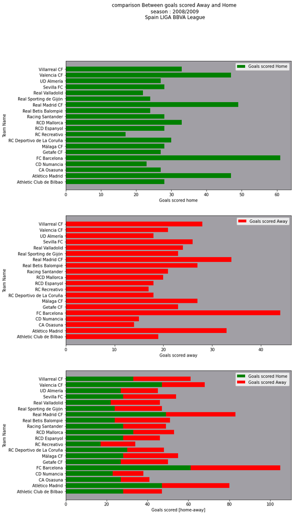

```python
compare_goals('2008/2009','Spain LIGA BBVA',df_matches_spain)
```

> **season 2008/2009 :**  
> *Barcelona* has the heighest score with more than **100** goals most of them scored **Home**  
> *Real Madrid* has the second heighest score with more than **80** goals most of them scored **Home**  
> *Atlitco Madrid* has the third heighest score with **80** goalsmost of them scored **Home**  
> *Recreativo* has the lowest score with less than **40** goals

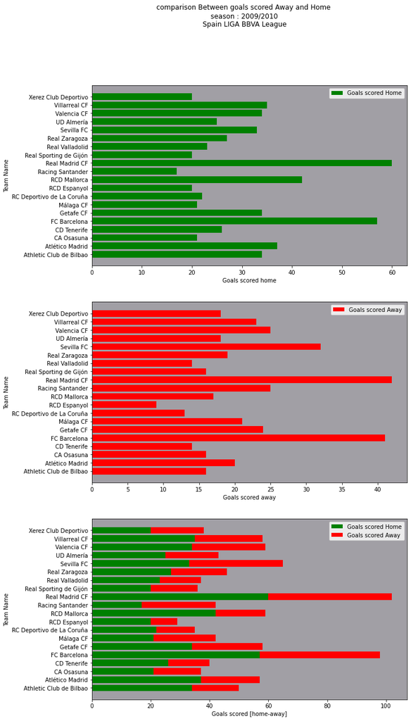

```python
compare_goals('2009/2010','Spain LIGA BBVA',df_matches_spain)
```

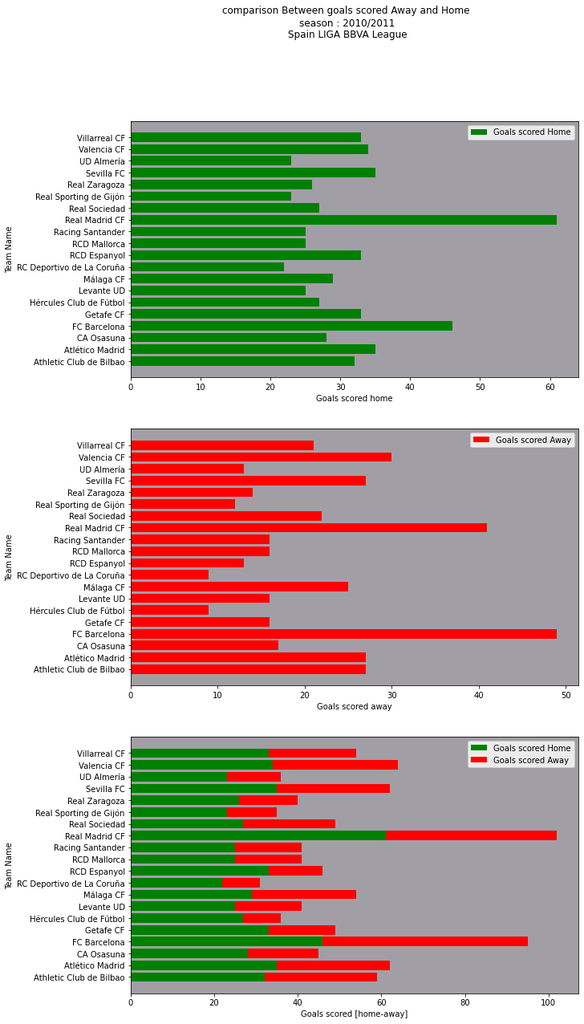

```python
compare_goals('2010/2011','Spain LIGA BBVA',df_matches_spain)
```

> **season 2010/2011 :**  
> *Real Madrid* has the heighest score with more than **100** goals most of them scored **Home**  
> *Barcelona* has the second heighest score with less than **100** goals most of them scored **Away**  
> *Valencia* has the third heighest score with **60** goals most of them scored **Home**  
> *Deportivo de la coruna* has the lowest score with less than **40** goals

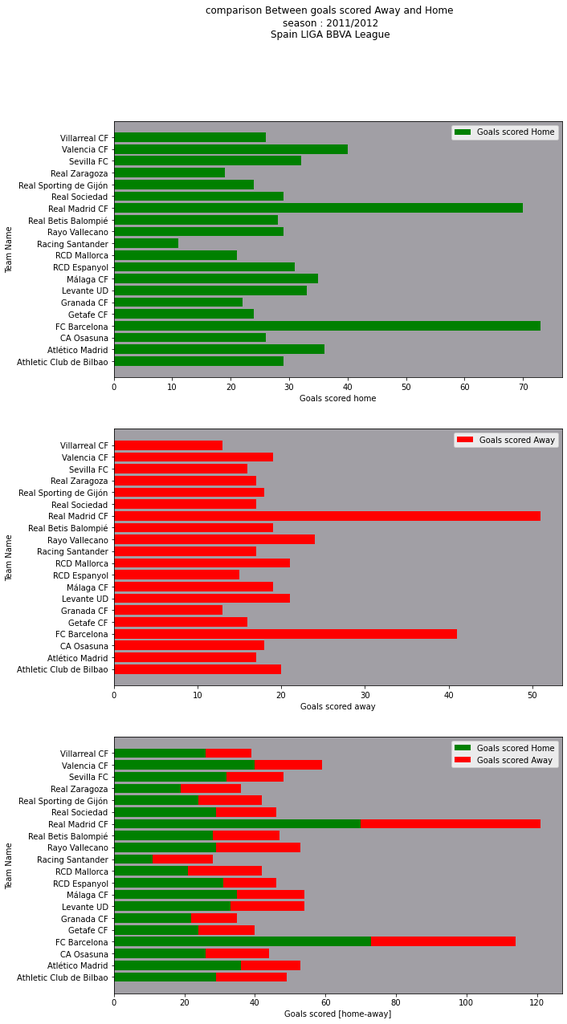

```python
compare_goals('2011/2012','Spain LIGA BBVA',df_matches_spain)
```

> **season 2011/2012 :**  
> *Real Madrid* has the heighest score with **120** goals most of them scored **Home**  
> *Barcelona* has the second heighest score with more than **100** goals most of them scored **Home**  
> *Valencia* has the third heighest score with **60** goals most of them scored **Home**  
> *Racing santander* has the lowest score with less than **40** goals

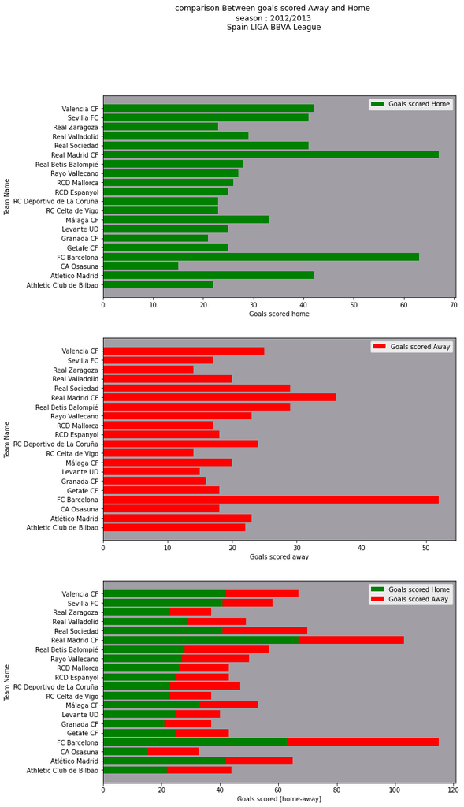

```python
compare_goals('2012/2013','Spain LIGA BBVA',df_matches_spain)
```

> **season 2012/2013 :**  
> *Barcelona* has the heighest score with more than **100** goals most of them scored **Home**  
> *Real Madrid* has the second heighest score with more than **100** goals most of them scored **Home**  
> *Real sociedad* has the third heighest score with more than **60** goals most of them scored **Home**  
> *Osasuna* has the lowest score with less than **40** goals

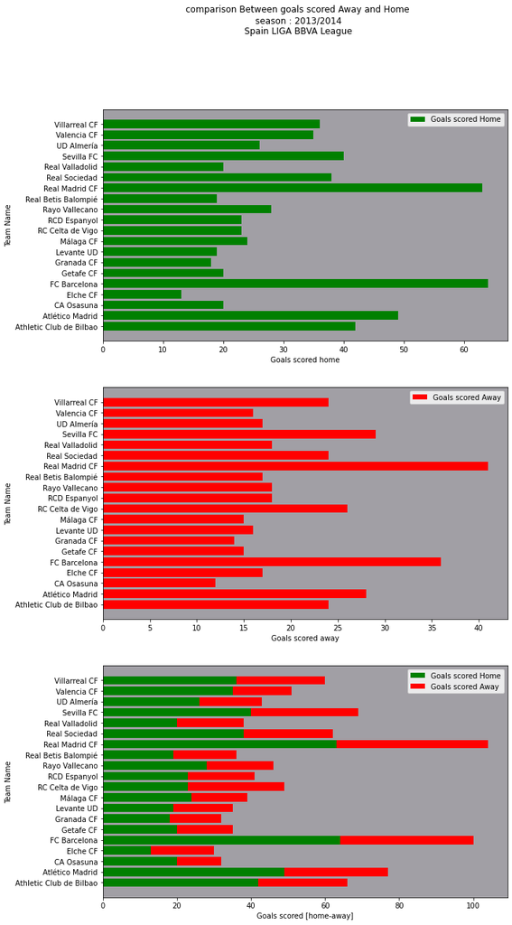

```python
compare_goals('2013/2014','Spain LIGA BBVA',df_matches_spain)
```

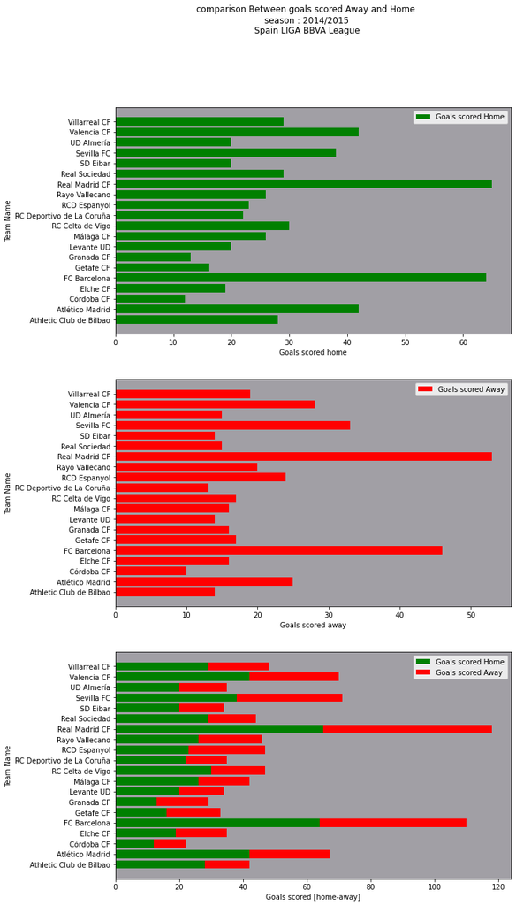

```python
compare_goals('2014/2015','Spain LIGA BBVA',df_matches_spain)
```

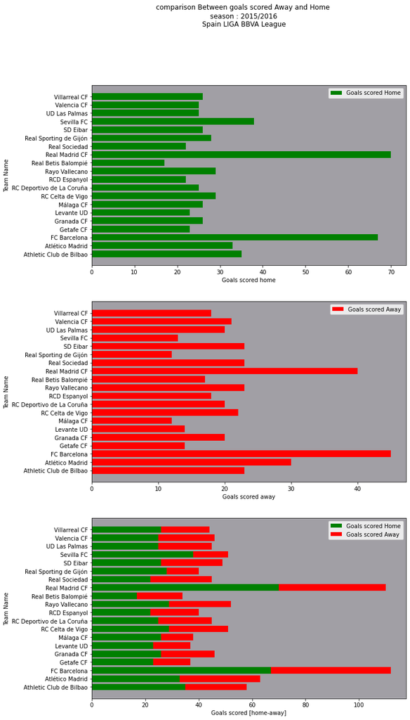

```python
compare_goals('2015/2016','Spain LIGA BBVA',df_matches_spain)
```

> **season 2015/2016 :**  
> *Barcelona* has the heighest score with more than **100** goals most of them scored **Home**  
> *Real Madrid* has the second heighest score with more than **100** goals most of them scored **Home**  
> *Atletico Madrid* has the third heighest score with **60** goals most of them scored **Home**  
> *Real betis balompie* has the lowest score with less than **40** goals

### Research Question 2 :

### How is the player's physical power related to weight and height?

> **Main Points** :
> 1. *The physical power can be determined by some attributes like Acceleration, Agility, Balance, jumping, stamina and strength*
> 2. *select specific date to deal with*
> 3. *Find the distribution of weight*
> 4. *Find the distribution of height*
> 5. *Check if there any correlation between weight and height*
> 6. *Check for the correaltion between weight and all the attributes*
> 7. *Check for the correaltion between height and all the attributes*

>    **Note: use correlation value $R^2$ such that : $R^2 \approx \pm 0.4$** or higher

```python
physical_attr = df_players_info[['player_name','date','acceleration','agility','balance','jumping','stamina','strength','reactions','weight','height']]
```

```python
# select data within date 2007-02-22
# you can find unique dates in the previous phase Data Wrangling
physical_attr_227 = physical_attr.query('date == 20070222')
# make sure datatypes are consistent
physical_attr_227 = physical_attr_227.infer_objects()
```

#### ...................................................View the distribution of Weight.....................................................

```
The mean value of weight is 168.44942294636795
```

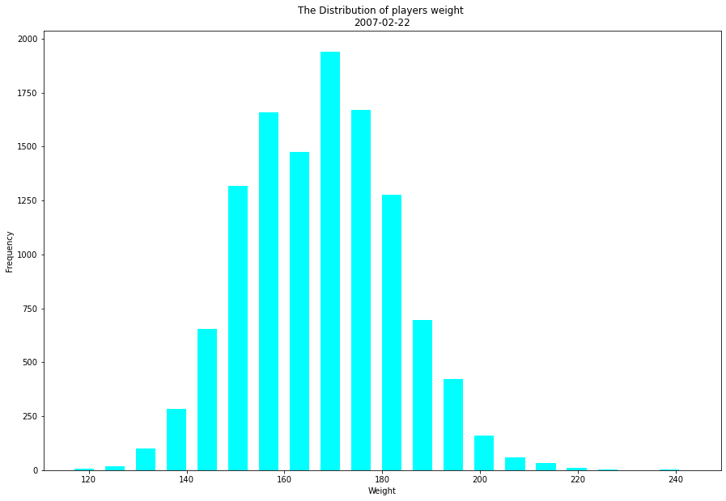

```python
# view the distribution of players weight in this date
weight = physical_attr_227['weight']
plt.figure(figsize=(15,10))
plt.title("The Distribution of players weight "+"\n2007-02-22")
plt.ylabel("Frequency")
plt.xlabel("Weight")
plt.hist( weight,bins = 20,color='cyan',width=4);
print("The mean value of weight is {}".format(np.mean(weight)))
```

*The players weight are normally distributed*

#### ...................................................View the distribution of Height.....................................................

```
The mean value of height is 181.86908689747958
```

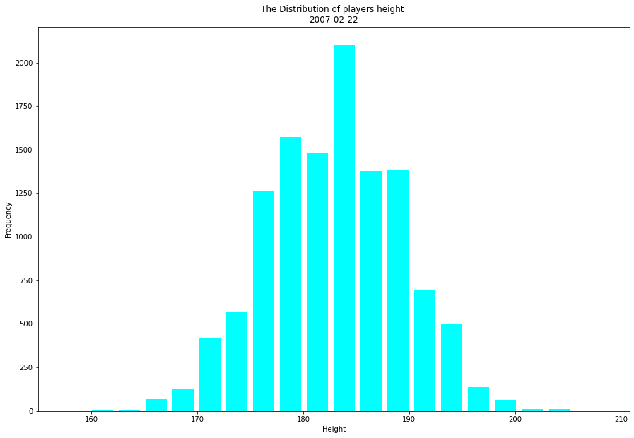

```python
# view the distribution of players height in this date
height = physical_attr_227['height']
plt.figure(figsize=(15,10))
plt.title("The Distribution of players height "+"\n2007-02-22")
plt.ylabel("Frequency")
plt.xlabel("Height")
plt.hist( height,bins =20,color='cyan',width=2);
print("The mean value of height is {}".format(np.mean(height)))
```

*The same thing for players height*

#### .......................................View the correlation between Height and Weight...................................

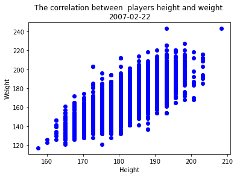

```python
# let's see if there any correlation between weight and height
height = physical_attr_227['height']
weight = physical_attr_227['weight']
plt.title("The correlation between  players height and weight "+"\n2007-02-22")
plt.ylabel("Weight")
plt.xlabel("Height")
plt.scatter( height, weight, color='blue');
```

*There is a positive correlation between Hight and weight*

#### .....................................View Which attribute has a correlation with Weight...................................

```python
# build a correlation matrix between weight and all the other attributes
weight_correlation_matrix =physical_attr_227[['acceleration','agility','balance','jumping','stamina','strength','reactions','weight']].corr()
weight_correlation_matrix
```

|  | acceleration | agility | balance | jumping | stamina | strength | reactions | weight |
| --- | --- | --- | --- | --- | --- | --- | --- | --- |
| acceleration | 1.000000 | 0.613982 | 0.454475 | 0.130513 | 0.474922 | 0.052010 | 0.411562 | -0.337811 |
| agility | 0.613982 | 1.000000 | 0.472631 | 0.099194 | 0.286786 | -0.163240 | 0.310720 | -0.439215 |
| balance | 0.454475 | 0.472631 | 1.000000 | 0.351952 | 0.359711 | 0.048557 | 0.282136 | -0.220130 |
| jumping | 0.130513 | 0.099194 | 0.351952 | 1.000000 | 0.297487 | 0.338856 | 0.242815 | 0.175596 |
| stamina | 0.474922 | 0.286786 | 0.359711 | 0.297487 | 1.000000 | 0.483845 | 0.483094 | -0.061764 |
| strength | 0.052010 | -0.163240 | 0.048557 | 0.338856 | 0.483845 | 1.000000 | 0.337293 | 0.410662 |
| reactions | 0.411562 | 0.310720 | 0.282136 | 0.242815 | 0.483094 | 0.337293 | 1.000000 | -0.016343 |
| weight | -0.337811 | -0.439215 | -0.220130 | 0.175596 | -0.061764 | 0.410662 | -0.016343 | 1.000000 |

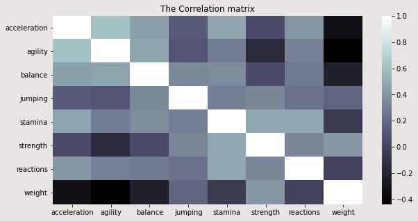

```python
fig = plt.figure(figsize=(10,5))
plt.title("The Correlation matrix")
fig.patch.set_facecolor("#E9E5E5")
sns.heatmap(weight_correlation_matrix,cmap = 'bone');
```

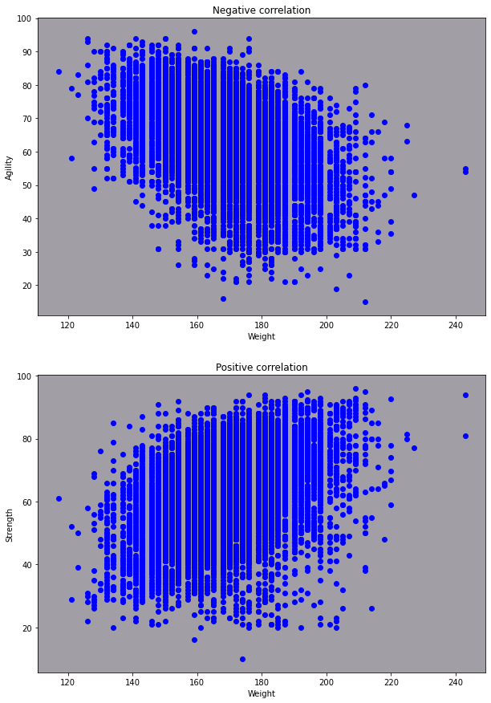

```python
# let's build a scatter plot for both correaltions
fig ,(ax1,ax2) = plt.subplots(2,figsize=(10,15))
fig.patch.set_facecolor("#FFFFFF")
weight = physical_attr_227['weight']
agility = physical_attr_227['agility']
strength = physical_attr_227['strength']
# scatter plot between weight and agility
ax1.set_facecolor('#A19FA5')
ax1.set_xlabel("Weight")
ax1.set_ylabel("Agility")
ax1.set_title("Negative correlation")
ax1.scatter(weight,agility,color ='blue');
# scatter plot between weight and strenght
ax2.set_facecolor('#A19FA5')
ax2.set_xlabel("Weight")
ax2.set_ylabel("Strength")
ax2.set_title("Positive correlation")
ax2.scatter(weight,strength,color ='blue');
```

*- weight and agility has a negative correlation*  
*- weight and strength has a positive correaltion*

#### .............................................Repeat the same process to the Height.............................................

*According to previous steps weight and Height has a positive correlation.Hence, we must find a correlation between height and agility and strength*

```python
# build a correlation matrix between Height and all the other attributes
height_correlation_matrix = physical_attr_227[['acceleration','agility','balance','jumping','stamina','strength','reactions','height']].corr()
height_correlation_matrix
```

|  | acceleration | agility | balance | jumping | stamina | strength | reactions | height |
| --- | --- | --- | --- | --- | --- | --- | --- | --- |
| acceleration | 1.000000 | 0.613982 | 0.454475 | 0.130513 | 0.474922 | 0.052010 | 0.411562 | -0.405290 |
| agility | 0.613982 | 1.000000 | 0.472631 | 0.099194 | 0.286786 | -0.163240 | 0.310720 | -0.507899 |
| balance | 0.454475 | 0.472631 | 1.000000 | 0.351952 | 0.359711 | 0.048557 | 0.282136 | -0.306263 |
| jumping | 0.130513 | 0.099194 | 0.351952 | 1.000000 | 0.297487 | 0.338856 | 0.242815 | 0.161593 |
| stamina | 0.474922 | 0.286786 | 0.359711 | 0.297487 | 1.000000 | 0.483845 | 0.483094 | -0.117280 |
| strength | 0.052010 | -0.163240 | 0.048557 | 0.338856 | 0.483845 | 1.000000 | 0.337293 | 0.368340 |
| reactions | 0.411562 | 0.310720 | 0.282136 | 0.242815 | 0.483094 | 0.337293 | 1.000000 | -0.083399 |
| height | -0.405290 | -0.507899 | -0.306263 | 0.161593 | -0.117280 | 0.368340 | -0.083399 | 1.000000 |

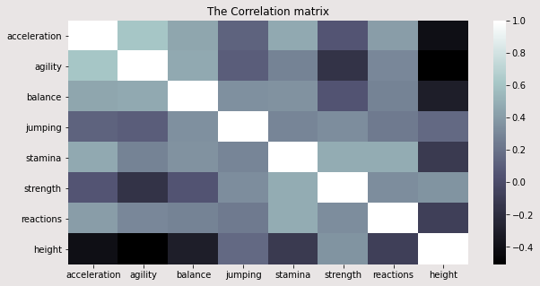

```python
# let's make the correlation matrix clear by using a heatmap
fig = plt.figure(figsize=(10,5))
plt.title("The Correlation matrix")
fig.patch.set_facecolor("#E9E5E5")
sns.heatmap(height_correlation_matrix,cmap = 'bone');
```

*The Height has a negative correlation with agility and acceleration*  
*The Height has a positve correlation with strength*

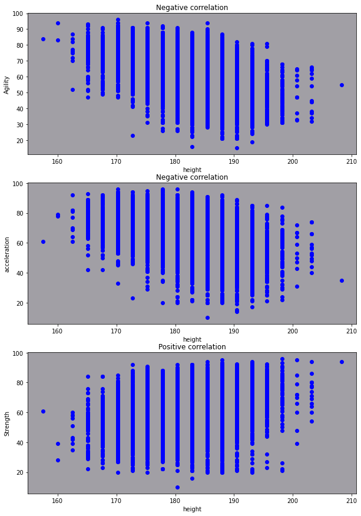

```python
# let's build a scatter plot for both correaltions
fig ,(ax1,ax2,ax3) = plt.subplots(3,figsize=(10,15))
fig.patch.set_facecolor("#FFFFFF")
height = physical_attr_227['height']
agility = physical_attr_227['agility']
acceleration = physical_attr_227['acceleration']
strength = physical_attr_227['strength']
# scatter plot between weight and agility
ax1.set_facecolor('#A19FA5')
ax1.set_xlabel("height")
ax1.set_ylabel("Agility")
ax1.set_title("Negative correlation")
ax1.scatter(height,agility,color ='blue');
# scatter plot between weight and acceleration
ax2.set_facecolor('#A19FA5')
ax2.set_xlabel("height")
ax2.set_ylabel("acceleration")
ax2.set_title("Negative correlation")
ax2.scatter(height,acceleration,color ='blue');
# scatter plot between weight and strenght
ax3.set_facecolor('#A19FA5')
ax3.set_xlabel("height")
ax3.set_ylabel("Strength")
ax3.set_title("Positive correlation")
ax3.scatter(height,strength,color ='blue');
```

### Research Question 3 :

### How did the number of red cards change from 2008 to 2016?

> **Main Points** :
> 1. define a function to filter the cards_info data by card_tpe ,date and get the sum of red cards that a player got within this date
> 2. *call the function using different dates*
> 3. *show how the number of red cards has changed from one date to another*

#### ----------------------------------define a function to filter the cards_info data----------------------------------

```python
# view the range of date
cards_info['date'].describe()
```

```
count                   61767
unique                   1347
top       2015-04-04 00:00:00
freq                      184
first     2008-08-15 00:00:00
last      2016-05-25 00:00:00
Name: date, dtype: object
```

```python
# will use this function multiple times with different date from 2008 to 2016
def invistigate_red_cards( df, table_name, start_date, end_date, card_type):
    """
    this function is to filter the cards_info data by date and sum over card_type then join it with players
    table using sql
    inputs :
    df ---------------------> DataFrame----------> dataframe to store the result
    table_name -------------> String ------------> the name of the table
    start_date -------------> String ------------> the date to filter with in format yyyy0101
    end_date -------------> String ------------> the date to filter with in format yyyy0101
    ouputs :
    df -------------------> DataFrame----------> dataframe after filtering and joining with players table
    """
    if card_type == 'y':
        card_type = '!='
    else :
        card_type = '=='
    # we have to filter players with red cards and within satrt_date to end_date
    query = 'card_type {} "r" and {}< date <{}'.format( card_type, start_date, end_date)
    df = cards_info.query(query)
    # we want to group the data by player id and count corresponding card type
    df = df.groupby(['player_id'])['card_type'].count().reset_index()
    # check if the table exist or not
    try :
        # save the dataframe into a table called red_card_2008 load it into the datebase
        load_table( df, table_name, False, {'player_id':Integer(),'card_type':Integer()})
    except ValueError:
        print("The table  already exists")
    # query the result of joining the two tables players and red_card_2008
    query = """
    SELECT p.player_name,r.card_type
    FROM (SELECT DISTINCT player_api_id,player_name  FROM Player) as p
    JOIN {} as r on(p.player_api_id = r.player_id);
    """.format(table_name)
    df = make_Query(query)
    return df
```

#### -------------------------------------call the function using different dates---------------------------------------

```python
red_card_2008 = pd.DataFrame()
red_card_2008 = invistigate_red_cards( red_card_2008, 'red_card_2008', '20080101', '20090101','r')

yellow_card_2008 = pd.DataFrame()
yellow_card_2008 = invistigate_red_cards( yellow_card_2008, 'yellow_card_2008', '20080101', '20090101','y')
```

```
The table  already exists
The table  already exists
```

```python
red_card_2009 = pd.DataFrame()
red_card_2009 = invistigate_red_cards( red_card_2009, 'red_card_2009', '20090101', '20100101','r')

yellow_card_2009 = pd.DataFrame()
yellow_card_2009 = invistigate_red_cards( yellow_card_2009, 'yellow_card_2009', '20090101', '20100101','y')
```

```
The table  already exists
The table  already exists
```

```python
red_card_2010 = pd.DataFrame()
red_card_2010 = invistigate_red_cards( red_card_2010, 'red_card_2010', '20100101', '20110101','r')

yellow_card_2010 = pd.DataFrame()
yellow_card_2010 = invistigate_red_cards( yellow_card_2010, 'yellow_card_2010', '20100101', '20110101','y')
```

```
The table  already exists
The table  already exists
```

```python
red_card_2011 = pd.DataFrame()
red_card_2011 = invistigate_red_cards( red_card_2011, 'red_card_2011', '20110101', '20120101','r')

yellow_card_2011 = pd.DataFrame()
yellow_card_2011 = invistigate_red_cards( yellow_card_2011, 'yellow_card_2011', '20110101', '20120101','y')
```

```
The table  already exists
The table  already exists
```

```python
red_card_2012 = pd.DataFrame()
red_card_2012 = invistigate_red_cards( red_card_2012, 'red_card_2012', '20120101', '20130101','r')

yellow_card_2012 = pd.DataFrame()
yellow_card_2012 = invistigate_red_cards( yellow_card_2012, 'yellow_card_2012', '20120101', '20130101','y')
```

```
The table  already exists
The table  already exists
```

```python
red_card_2013 = pd.DataFrame()
red_card_2013 = invistigate_red_cards( red_card_2013, 'red_card_2013', '20130101', '20140101','r')

yellow_card_2013 = pd.DataFrame()
yellow_card_2013 = invistigate_red_cards( yellow_card_2013, 'yellow_card_2013', '20130101', '20140101','y')
```

```
The table  already exists
The table  already exists
```

```python
red_card_2014 = pd.DataFrame()
red_card_2014 = invistigate_red_cards( red_card_2014, 'red_card_2014', '20140101', '20150101','r')

yellow_card_2014 = pd.DataFrame()
yellow_card_2014 = invistigate_red_cards( yellow_card_2014, 'yellow_card_2014', '20140101', '20150101','y')
```

```
The table  already exists
The table  already exists
```

```python
red_card_2015 = pd.DataFrame()
red_card_2015 = invistigate_red_cards( red_card_2015, 'red_card_2015', '20150101', '20160101','r')

yellow_card_2015 = pd.DataFrame()
yellow_card_2015 = invistigate_red_cards( yellow_card_2015, 'yellow_card_2015', '20150101', '20160101','y')
```

```
The table  already exists
The table  already exists
```

```python
red_card_2016 = pd.DataFrame()
red_card_2016 = invistigate_red_cards( red_card_2016, 'red_card_2016', '20160101', '20170101','r')

yellow_card_2016 = pd.DataFrame()
yellow_card_2016 = invistigate_red_cards( yellow_card_2016, 'yellow_card_2016', '20160101', '20170101','y')
```

```
The table  already exists
The table  already exists
```

#### -------------------------------show how the number of red cards has changed--------------------------------

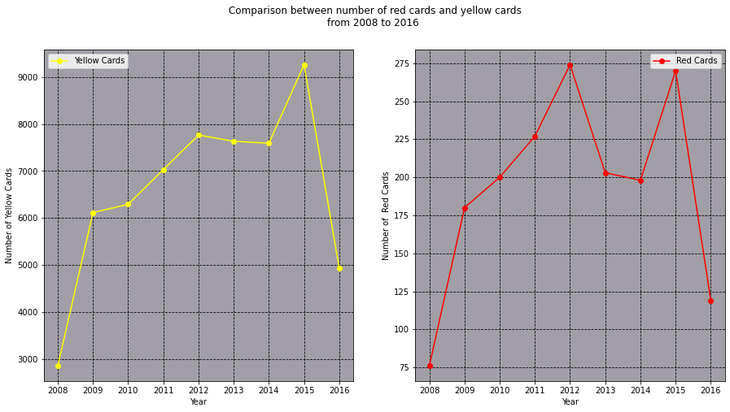

```python
# let's store the sum of all red/yellow cards in each season
red_cards_full = [ red_card_2008, red_card_2009, red_card_2010, red_card_2011, red_card_2012, red_card_2013, red_card_2014, red_card_2015, red_card_2016]
yellow_cards_full = [ yellow_card_2008, yellow_card_2009, yellow_card_2010, yellow_card_2011, yellow_card_2012, yellow_card_2013, yellow_card_2014, yellow_card_2015, yellow_card_2016]
x = ['2008','2009','2010','2011','2012','2013','2014','2015','2016']
y1 = []
y2 = []
for element in red_cards_full :
    y1.append(element.card_type.sum())
for element in yellow_cards_full :
    y2.append(element.card_type.sum())
fig , (ax1 , ax2) = plt.subplots(1,2,figsize=(15,7.5)) # we will plot two figures
fig.suptitle(" Comparison between number of red cards and yellow cards"+"\nfrom 2008 to 2016")
fig.patch.set_facecolor("#FFFFFF")
# plot first line chart for yellow cards
ax1.set_xlabel("Year")
ax1.set_ylabel("Number of Yellow Cards")
ax1.set_facecolor('#A19FA5')
ax1.grid(color='black',linestyle='dashed')
ax1.plot(x,y2,color= 'yellow',markersize = 12,marker='.',linewidth = 1.5,label="Yellow Cards");
ax1.legend();
# plot first line chart for yellow cards
ax2.set_xlabel("Year")
ax2.set_ylabel("Number of  Red Cards")
ax2.set_facecolor('#A19FA5')
ax2.grid(color='black',linestyle='dashed')
ax2.plot(x,y1,color= 'red',markersize = 12,marker='.',linewidth = 1.5,label="Red Cards");
ax2.legend();
```

## Limitations

> **Lacke of information** is one of the limitations that I have encountered while dealing with this database *for example* there wasn't a foreign key team_api_id in the players' table that prevent us from relating the players' table with the teams' table.in addition to that,**data inconsistency** is another issue the database itself is consistent but some columns like card, goal, shot off,..etc written in XML format aren't consistent *for example :* in the card column, you might find a player_id but without specifying card_type or vice versa. **other issue** like different date ranges were used *for example :* in the players' table, you might find some players' date ranges from 2008 to 2012 and others from 2012 to 2014 that make it impossible to deal with all the players on the same date.

## Resources

$\bullet$ This website helped me a lot to understand the structure of xml file visit the site [here](https://www.anyjson.in/xml-to-table)  
$\bullet$ Kaggle [website](https://www.kaggle.com/datasets/hugomathien/soccer/discussion?search=g) for soccer database  
$\bullet$ This website taught me [LaTeX mathematical symbols](https://oeis.org/wiki/List_of_LaTeX_mathematical_symbols)